# Permutation

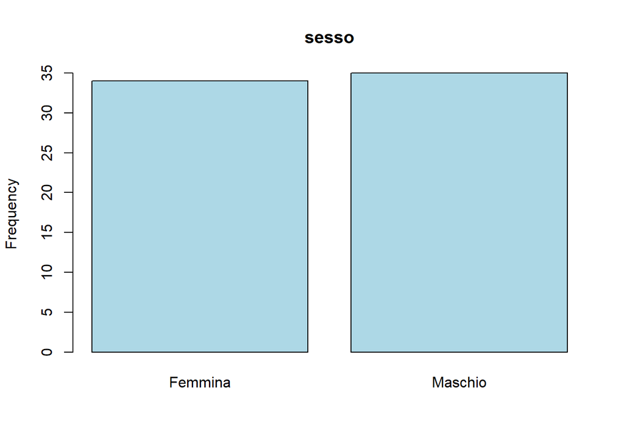

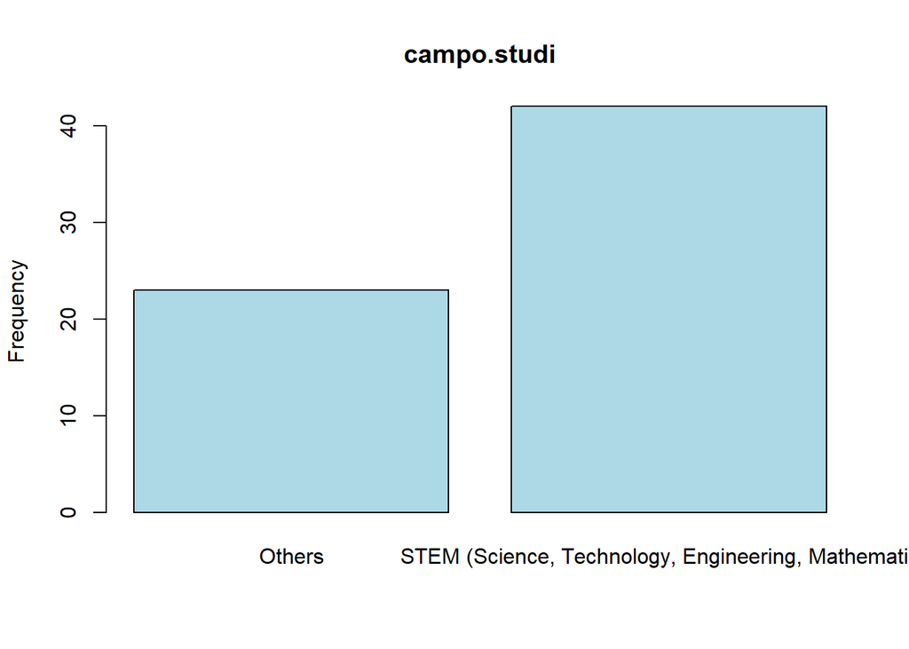

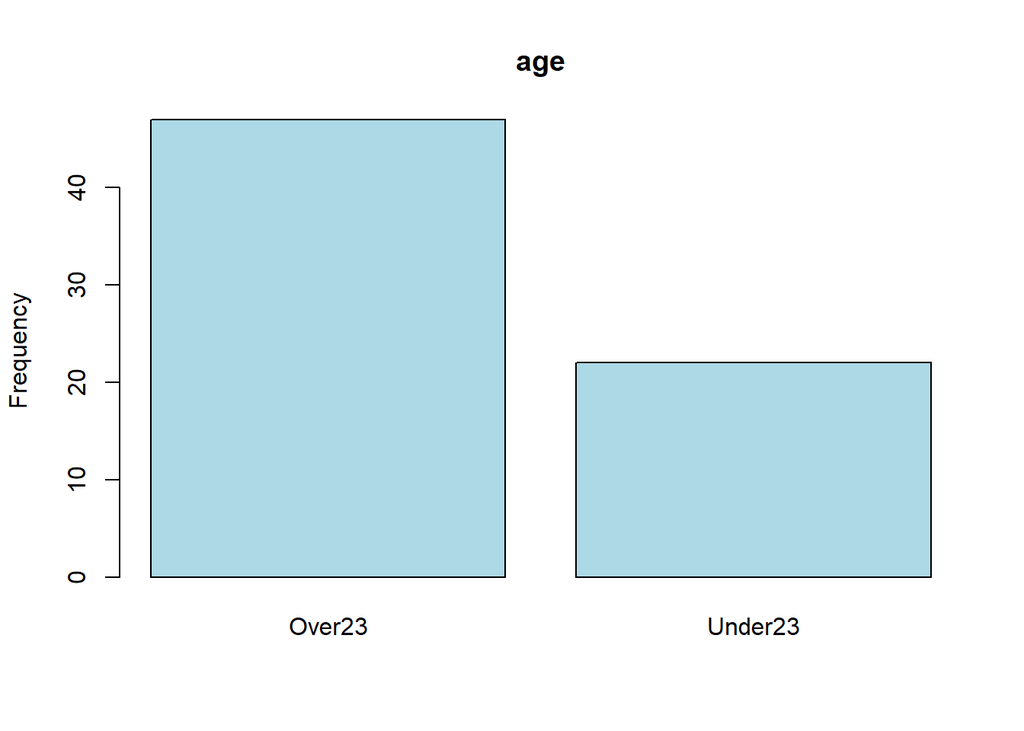

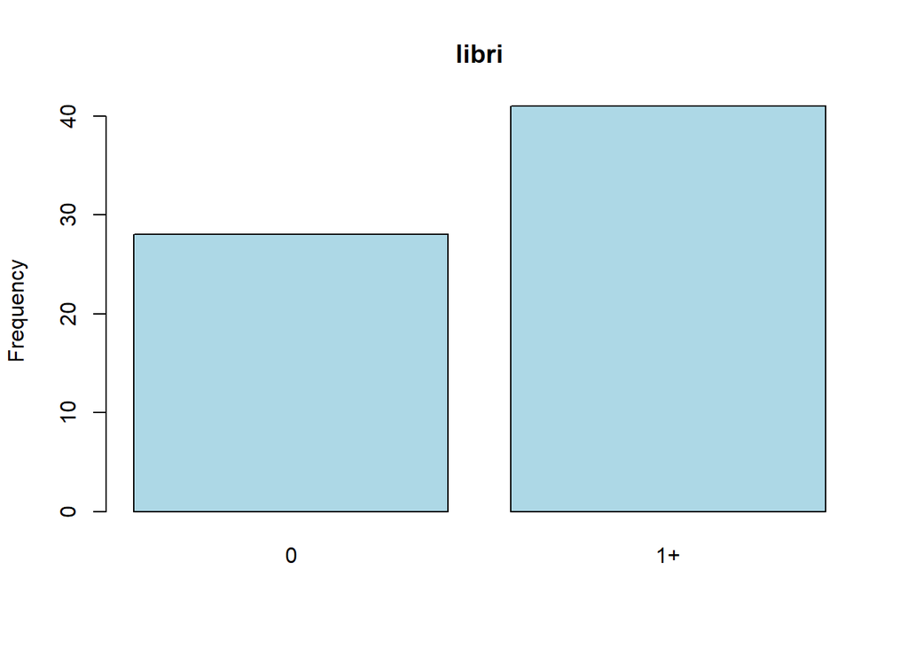

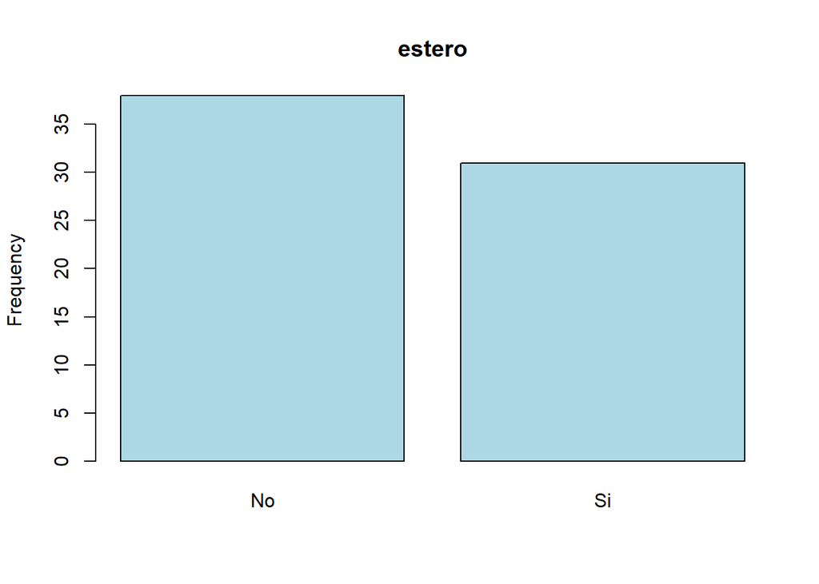

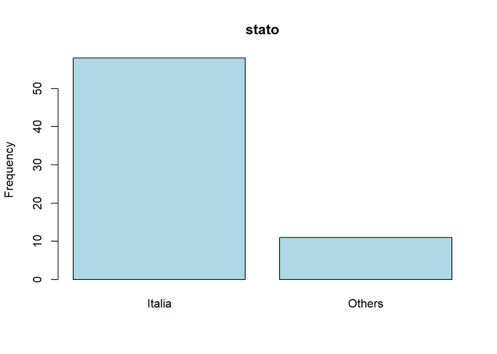

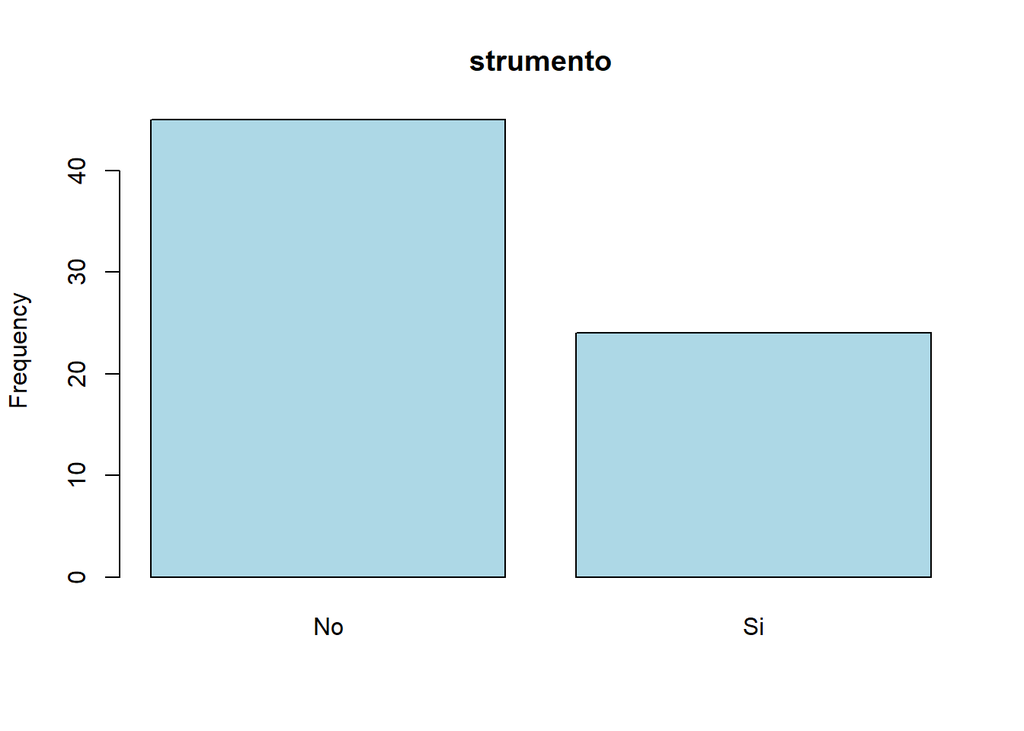

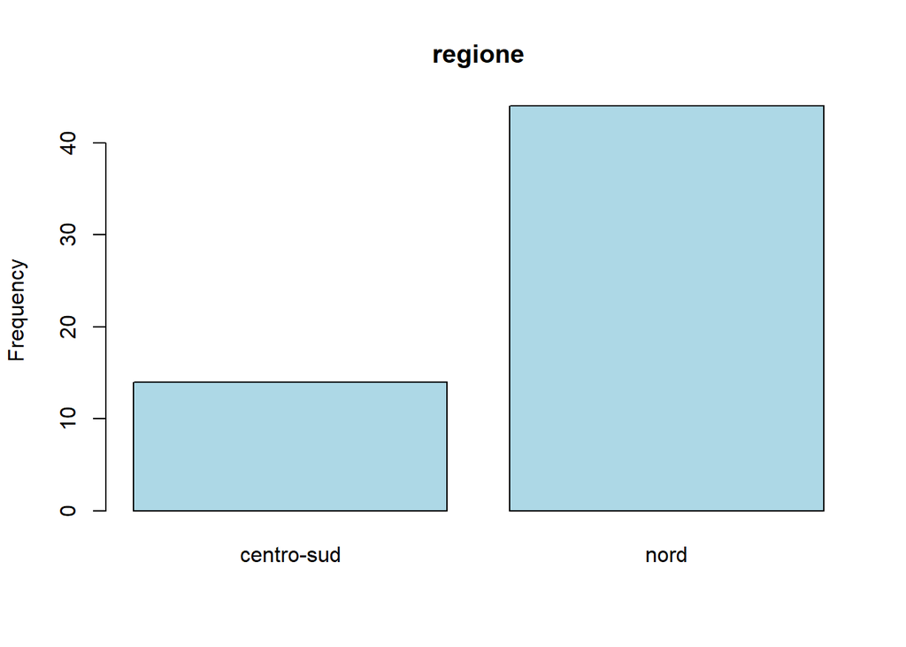

```r
selected_indices <- c(2,4,1,6,13,5,12,15)
selected_data <- survey_data[, selected_indices]


for (i in seq_along(selected_indices)) {

  barplot(table(selected_data[, i]), col = "lightblue",
          main = colnames(selected_data)[i], xlab = "", ylab = "Frequency")
}
```

## One-way Anova

```r
#Non parametric one way anova function
one_way_anova <- function(x, cat, iter=1e3){
  T_stat <- numeric(iter)
  n <- length(x)
  fit <- aov(x ~ cat)
  T0 <- summary(fit)[[1]][1,4]


  for(perm in 1:iter){
    # Permutation:
    permutation <- sample(1:n)
    x_perm <- x[permutation]
    fit_perm <- aov(x_perm ~ cat)

    # Test statistic:
    T_stat[perm] <- summary(fit_perm)[[1]][1,4]
  }
  p_val <- sum(T_stat>=T0)/iter
  return (p_val)
}
```

```r
#One way anova on all 12 covariates with extraction

my_one_way <- function(cat){
  res <- vector("numeric", length = 12)
  for (j in 1:12) {
    #missing
    res[j] <- one_way_anova(unlist(median_data[,j]), cat)
  }
  return(res)
}
```

```r
median_data <- numeric_data %>%
        group_by(id) %>%
        summarise(across(everything(), median))
```

```r
id_col<-median_data$id
median_data<-median_data[,-1]
median_data$id<-id_col
```

### Anova Permutation test for Work

```r
res_work<-my_one_way(survey_data$lavoro)
res_work
```

```
##  [1] 0.084 0.032 0.302 0.055 0.132 0.988 0.056 0.923 0.024 0.502 0.457 0.958
```

### Anova Permutation test for Importance of music

```r
res_importance.music<-my_one_way(survey_data$importanza.musica)
res_importance.music
```

```
##  [1] 0.084 0.803 0.211 0.876 0.405 0.750 0.806 0.738 0.814 0.490 0.968 0.674
```

### Anova Permutiation test for How do you listen to music

```r
res_how.listen<-my_one_way(survey_data$come.ascolti.musica)
res_how.listen
```

```
##  [1] 0.620 0.651 0.325 0.965 0.811 0.973 0.961 0.360 0.553 0.814 0.628 0.269
```

### Anova Permutation test for Number of concerts

```r
# Define the breakpoints for the categories
breakpoints <- c(-Inf, 1, 3, Inf)

# Create a new categorical column based on the numeric_column
survey_data$concerti <- cut(survey_data$concerti, breaks = breakpoints, labels = c("<=1", "(1,3]", ">3"), include.lowest = TRUE)
```

rejecting H0: none. Possible to change the division of the data

```r
res_concerts<-my_one_way(survey_data$concerti)
res_concerts
```

```
##  [1] 0.479 0.360 0.277 0.639 0.663 0.500 0.858 0.327 0.491 0.215 0.465 0.390
```

### Anova Permutation for Number of inhabitants

```r
table(survey_data$abitanti.citta)
```

```
##
##          Meno di 1000 abitanti        Più di 500 000 abitanti
##                              1                             35
##    Tra 1.000 e 10.000 abitanti           Tra 10.000 e 100.000
##                              5                             11
## Tra 100.000 e 500.000 abitanti
##                             17
```

```r
# Transform the column based on conditions
survey_data <- survey_data %>%
  mutate(
    abitanti.citta = case_when(
      abitanti.citta %in% c("Meno di 1000 abitanti", "Tra 1.000 e 10.000 abitanti", "Tra 10.000 e 100.000") ~ "Meno di 100.000 abitanti",
      TRUE ~ abitanti.citta
    )
  )
table(survey_data$abitanti.citta)
```

```
##
##       Meno di 100.000 abitanti        Più di 500 000 abitanti
##                             17                             35
## Tra 100.000 e 500.000 abitanti
##                             17
```

```r
survey_data <- survey_data %>%
  mutate(abitanti.citta= case_when(
    abitanti.citta %in% c("Meno di 1000 abitanti", "Tra 1.000 e 10.000 abitanti") ~ "Meno di 100.000 abitanti",
    abitanti.citta == "Tra 100.000 e 500.000 abitanti" ~ "Tra 100.000 e 500.000 abitanti",
    abitanti.citta == "Più di 500 000 abitanti" ~ "Più di 500 000 abitanti",
    TRUE ~ abitanti.citta
  ))
table(survey_data$abitanti.citta)
```

```
##
##       Meno di 100.000 abitanti        Più di 500 000 abitanti
##                             17                             35
## Tra 100.000 e 500.000 abitanti
##                             17
```

```r
res_inhabitants<-my_one_way(survey_data$abitanti.citta)
res_inhabitants
```

```
##  [1] 0.953 0.195 0.990 0.323 0.807 0.906 0.615 0.914 0.115 0.986 0.842 0.818
```

### Anova Permutation for Genre

We consider only people in the most listened genres, since it doesn’t make sense compare other genres with to few people (hiphop,pop,rock)

```r
genre_counts<-table(survey_data$genere)
selected_genres <- names(genre_counts[genre_counts > 10])

survey_data$genere[!(survey_data$genere %in% selected_genres)] <- NA

table(survey_data$genere)
```

```
##
##  classical electronic       folk     hiphop       jazz      metal    missing
##          0          0          0         14          0          0          0
##        pop       rock       soul
##         28         12          0
```

```r
res_genre<-my_one_way(survey_data$genere)
res_genre
```

```
##  [1] 0.891 0.110 0.139 0.212 0.224 0.777 0.195 0.911 0.697 0.009 0.099 0.098
```

Let’s bind results

```r
res_anova<-rbind(res_work,res_importance.music, res_how.listen, res_concerts, res_inhabitants, res_genre)
cnames<-colnames(numeric_data[,-13])
colnames(res_anova)<-cnames
```

```r
res<-rbind(res_perm,res_anova)
```

If we wanna use importanza.musica we need to rearrange somehow

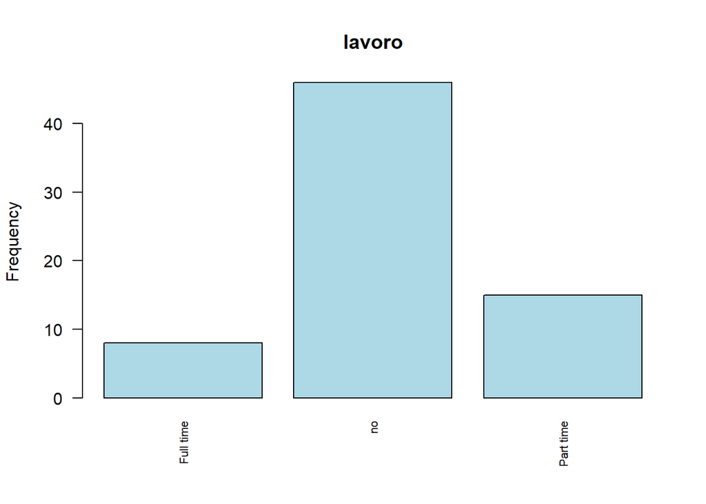

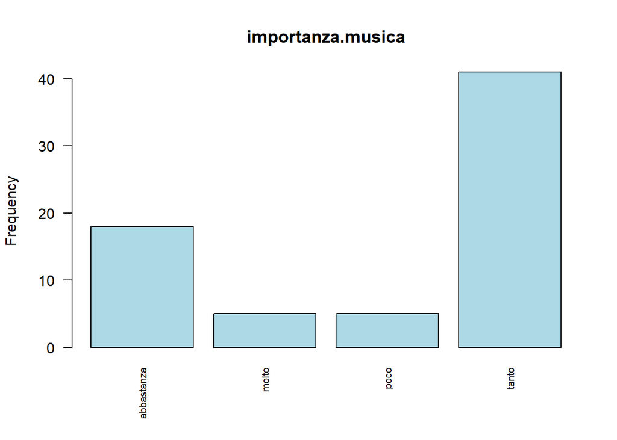

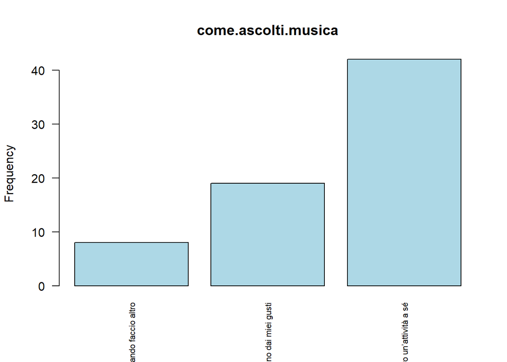

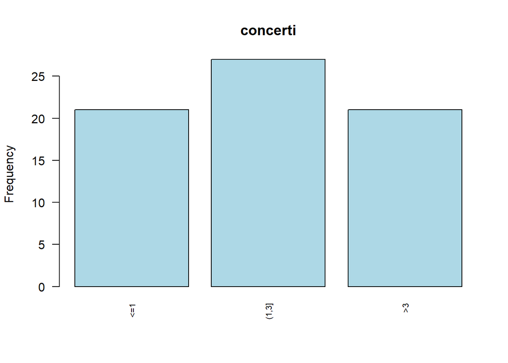

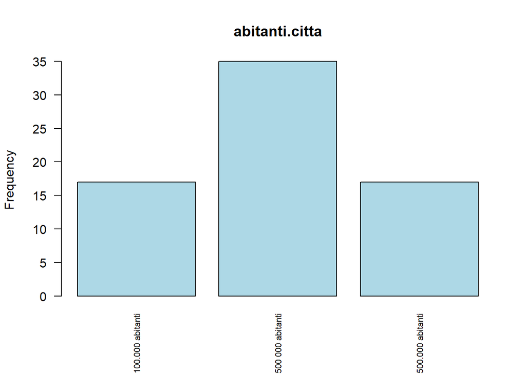

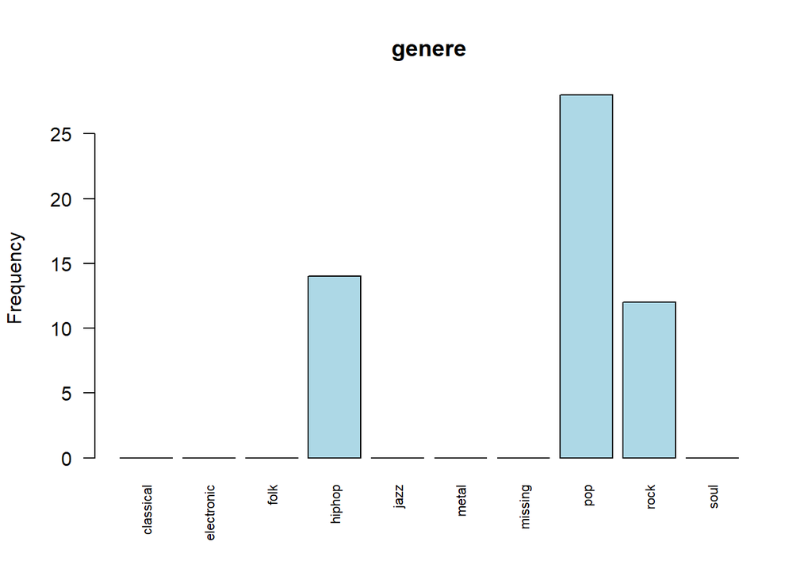

```r
selected_indices <- c(7,8,10,11,16,9)
selected_data <- survey_data[, selected_indices]


for (i in seq_along(selected_indices)) {

  barplot(table(selected_data[, i]), col = "lightblue",
          main = colnames(selected_data)[i], xlab = "", ylab = "Frequency",cex.names = 0.7, las=2)
}
```

## Results

Raga help non riesco a farlo stampare nell’ordine corretto, volevo colorare di rosso i pvalue delle categorie significative con alpha=0.05

```r
threshold <- 0.05
condition0.05 <- ifelse(res< threshold, 1, 0)

condition0.05<-as.data.frame(condition0.05)
count0.05<-numeric()
for (i in 1:12){
count0.05[i]<-sum(condition0.05[,i]==1)}

threshold <- 0.1
condition0.1 <- ifelse(res< threshold, 1, 0)

condition0.1<-as.data.frame(condition0.1)
count0.1<-numeric()
for (i in 1:12){
count0.1[i]<-sum(condition0.1[,i]==1)}
```

```r
reduced<-survey_data[,-c(3,14)]
```

```r
saveRDS(res,"../../data/pvalues_cat.RData")
saveRDS(reduced,"../../data/survey_reduced.RData")
```

## Two-way Anova

```r
survey_data<-readRDS("../../data/survey_reduced.RData")
res<-readRDS("../../data/pvalues_cat.RData")
```

###energy:age, abroad reject HO-> keep interaction p-value:0.048

```r
B=1000

T0_stat <- summary.aov(aov(median_data$energy~ survey_data$age+ survey_data$estero+survey_data$age:survey_data$estero))[[1]][3,4]
T0_stat
```

```
## [1] 3.692461
```

```r
aov.H0 <- aov(median_data$energy~ survey_data$age+ survey_data$estero)
aov.H0
```

```
## Call:
##    aov(formula = median_data$energy ~ survey_data$age + survey_data$estero)
##
## Terms:
##                 survey_data$age survey_data$estero Residuals
## Sum of Squares        0.0024896          0.0016652 0.6267163
## Deg. of Freedom               1                  1        66
##
## Residual standard error: 0.09744589
## Estimated effects may be unbalanced
```

```r
residuals.H0 <- aov.H0$residuals
n = length(median_data$energy)


T_stat <- numeric(B)
for(perm in 1:B){
  permutation <- sample(n)
  # permute the residuals
  residuals.H0 <- residuals.H0[permutation]
  perm.response.H0 <- aov.H0$fitted + residuals.H0
  # re-fit full model to calculate statistic
  T_stat[perm] <- summary.aov(aov(   perm.response.H0  ~ survey_data$age + survey_data$estero + survey_data$age:survey_data$estero))[[1]][3,4]
}
sum(T_stat >= T0_stat)/B
```

```
## [1] 0.048
```

### liveness: sex,abroad

```r
B=1000

T0_stat <- summary.aov(aov(median_data$liveness~ survey_data$sesso+ survey_data$estero+survey_data$sesso:survey_data$estero))[[1]][3,4]
T0_stat
```

```
## [1] 0.6440028
```

```r
aov.H0 <- aov(median_data$liveness~ survey_data$sesso+ survey_data$estero)
aov.H0
```

```
## Call:
##    aov(formula = median_data$liveness ~ survey_data$sesso + survey_data$estero)
##
## Terms:
##                 survey_data$sesso survey_data$estero   Residuals
## Sum of Squares        0.000110781        0.000002348 0.009538182
## Deg. of Freedom                 1                  1          66
##
## Residual standard error: 0.01202156
## Estimated effects may be unbalanced
```

```r
residuals.H0 <- aov.H0$residuals
n = length(median_data$liveness)


T_stat <- numeric(B)
for(perm in 1:B){
  permutation <- sample(n)
  # permute the residuals
  residuals.H0 <- residuals.H0[permutation]
  perm.response.H0 <- aov.H0$fitted + residuals.H0
  # re-fit full model to calculate statistic
  T_stat[perm] <- summary.aov(aov(   perm.response.H0  ~ survey_data$sesso + survey_data$estero + survey_data$sesso:survey_data$estero))[[1]][3,4]
}
sum(T_stat >= T0_stat)/B
```

```
## [1] 0.428
```

### acusticness: age,abroad,work (no interactions)

H1 all interaction, H0 no 3 interactions accept H0

```r
B=1000

T0_stat <- summary.aov(aov(median_data$acousticness~ survey_data$lavoro+ survey_data$age+ survey_data$estero+survey_data$lavoro:survey_data$estero+survey_data$lavoro:survey_data$age+survey_data$age:survey_data$estero+survey_data$lavoro:survey_data$estero:survey_data$age))[[1]][3,4]


aov.H0 <- aov(median_data$acousticness~ survey_data$lavoro+ survey_data$age+ survey_data$estero+survey_data$lavoro:survey_data$estero+survey_data$lavoro:survey_data$age+survey_data$age:survey_data$estero)


residuals.H0 <- aov.H0$residuals
n = length(median_data$acousticness)


T_stat <- numeric(B)
for(perm in 1:B){
  permutation <- sample(n)
  # permute the residuals
  residuals.H0 <- residuals.H0[permutation]
  perm.response.H0 <- aov.H0$fitted + residuals.H0
  # re-fit full model to calculate statistic
  T_stat[perm] <- summary.aov(aov(   perm.response.H0  ~ survey_data$lavoro+ survey_data$age+ survey_data$estero+survey_data$lavoro:survey_data$estero+survey_data$lavoro:survey_data$age+survey_data$age:survey_data$estero+survey_data$lavoro:survey_data$estero:survey_data$age))[[1]][3,4]
}
sum(T_stat >= T0_stat)/B
```

```
## [1] 0.592
```

H1 as before H0 remove estero:lavoro accept H0

```r
B=1000

T0_stat <- summary.aov(aov(median_data$acousticness~ survey_data$lavoro+ survey_data$age+ survey_data$estero+survey_data$lavoro:survey_data$estero+survey_data$lavoro:survey_data$age+survey_data$age:survey_data$estero))[[1]][3,4]


aov.H0 <- aov(median_data$acousticness~ survey_data$lavoro+ survey_data$age+ survey_data$estero+survey_data$lavoro:survey_data$age+survey_data$age:survey_data$estero)


residuals.H0 <- aov.H0$residuals
n = length(median_data$acousticness)


T_stat <- numeric(B)
for(perm in 1:B){
  permutation <- sample(n)
  # permute the residuals
  residuals.H0 <- residuals.H0[permutation]
  perm.response.H0 <- aov.H0$fitted + residuals.H0
  # re-fit full model to calculate statistic
  T_stat[perm] <- summary.aov(aov(   perm.response.H0  ~ survey_data$lavoro+ survey_data$age+ survey_data$estero+survey_data$lavoro:survey_data$estero+survey_data$lavoro:survey_data$age+survey_data$age:survey_data$estero))[[1]][3,4]
}
sum(T_stat >= T0_stat)/B
```

```
## [1] 0.582
```

H1 as before H0 remove estero:age accept H0

```r
B=1000

T0_stat <- summary.aov(aov(median_data$acousticness~ survey_data$lavoro+ survey_data$age+ survey_data$estero+survey_data$lavoro:survey_data$age+survey_data$age:survey_data$estero))[[1]][3,4]


aov.H0 <- aov(median_data$acousticness~ survey_data$lavoro+ survey_data$age+ survey_data$estero+survey_data$lavoro:survey_data$age)


residuals.H0 <- aov.H0$residuals
n = length(median_data$acousticness)


T_stat <- numeric(B)
for(perm in 1:B){
  permutation <- sample(n)
  # permute the residuals
  residuals.H0 <- residuals.H0[permutation]
  perm.response.H0 <- aov.H0$fitted + residuals.H0
  # re-fit full model to calculate statistic
  T_stat[perm] <- summary.aov(aov(   perm.response.H0  ~ survey_data$lavoro+ survey_data$age+ survey_data$estero+survey_data$lavoro:survey_data$age+survey_data$age:survey_data$estero))[[1]][3,4]
}
sum(T_stat >= T0_stat)/B
```

```
## [1] 0.591
```

H1 as before H0 remove lavoro:age accept H0

-> no interactions

```r
B=1000

T0_stat <- summary.aov(aov(median_data$acousticness~ survey_data$lavoro+ survey_data$age+ survey_data$estero+survey_data$lavoro:survey_data$age))[[1]][3,4]


aov.H0 <- aov(median_data$acousticness~ survey_data$lavoro+ survey_data$age+ survey_data$estero)


residuals.H0 <- aov.H0$residuals
n = length(median_data$acousticness)


T_stat <- numeric(B)
for(perm in 1:B){
  permutation <- sample(n)
  # permute the residuals
  residuals.H0 <- residuals.H0[permutation]
  perm.response.H0 <- aov.H0$fitted + residuals.H0
  # re-fit full model to calculate statistic
  T_stat[perm] <- summary.aov(aov(   perm.response.H0  ~ survey_data$lavoro+ survey_data$age+ survey_data$estero+survey_data$lavoro:survey_data$age))[[1]][3,4]
}
sum(T_stat >= T0_stat)/B
```

```
## [1] 0.552
```

### loudness: age, abroad, instrument (no interactions)

H1 all interaction, H0 no 3 interactions accept H0

```r
B=1000

T0_stat <- summary.aov(aov(median_data$loudness~ survey_data$strumento+ survey_data$age+ survey_data$estero+survey_data$strumento:survey_data$estero+survey_data$strumento:survey_data$age+survey_data$age:survey_data$estero+survey_data$strumento:survey_data$estero:survey_data$age))[[1]][3,4]


aov.H0 <- aov(median_data$loudness~ survey_data$strumento+ survey_data$age+ survey_data$estero+survey_data$strumento:survey_data$estero+survey_data$strumento:survey_data$age+survey_data$age:survey_data$estero)


residuals.H0 <- aov.H0$residuals
n = length(median_data$loudness)


T_stat <- numeric(B)
for(perm in 1:B){
  permutation <- sample(n)
  # permute the residuals
  residuals.H0 <- residuals.H0[permutation]
  perm.response.H0 <- aov.H0$fitted + residuals.H0
  # re-fit full model to calculate statistic
  T_stat[perm] <- summary.aov(aov(   perm.response.H0  ~ survey_data$strumento+ survey_data$age+ survey_data$estero+survey_data$strumento:survey_data$estero+survey_data$strumento:survey_data$age+survey_data$age:survey_data$estero+survey_data$strumento:survey_data$estero:survey_data$age))[[1]][3,4]
}
sum(T_stat >= T0_stat)/B
```

```
## [1] 0.963
```

H0 remove age:estero accept H0

```r
B=1000

T0_stat <- summary.aov(aov(median_data$loudness~ survey_data$strumento+ survey_data$age+ survey_data$estero+survey_data$strumento:survey_data$estero+survey_data$strumento:survey_data$age+survey_data$age:survey_data$estero))[[1]][3,4]


aov.H0 <- aov(median_data$loudness~ survey_data$strumento+ survey_data$age+ survey_data$estero+survey_data$strumento:survey_data$estero+survey_data$strumento:survey_data$age)


residuals.H0 <- aov.H0$residuals
n = length(median_data$loudness)


T_stat <- numeric(B)
for(perm in 1:B){
  permutation <- sample(n)
  # permute the residuals
  residuals.H0 <- residuals.H0[permutation]
  perm.response.H0 <- aov.H0$fitted + residuals.H0
  # re-fit full model to calculate statistic
  T_stat[perm] <- summary.aov(aov(   perm.response.H0  ~ survey_data$strumento+ survey_data$age+ survey_data$estero+survey_data$strumento:survey_data$estero+survey_data$strumento:survey_data$age+survey_data$age:survey_data$estero))[[1]][3,4]
}
sum(T_stat >= T0_stat)/B
```

```
## [1] 0.965
```

H0 remove age:strumento accept H0

```r
B=1000

T0_stat <- summary.aov(aov(median_data$loudness~ survey_data$strumento+ survey_data$age+ survey_data$estero+survey_data$strumento:survey_data$estero+survey_data$strumento:survey_data$age))[[1]][3,4]


aov.H0 <- aov(median_data$loudness~ survey_data$strumento+ survey_data$age+ survey_data$estero+survey_data$strumento:survey_data$estero)


residuals.H0 <- aov.H0$residuals
n = length(median_data$loudness)


T_stat <- numeric(B)
for(perm in 1:B){
  permutation <- sample(n)
  # permute the residuals
  residuals.H0 <- residuals.H0[permutation]
  perm.response.H0 <- aov.H0$fitted + residuals.H0
  # re-fit full model to calculate statistic
  T_stat[perm] <- summary.aov(aov(   perm.response.H0  ~ survey_data$strumento+ survey_data$age+ survey_data$estero+survey_data$strumento:survey_data$estero+survey_data$strumento:survey_data$age))[[1]][3,4]
}
sum(T_stat >= T0_stat)/B
```

```
## [1] 0.956
```

H0 remove estero:strumento accept H0 -> no interactions

```r
B=1000

T0_stat <- summary.aov(aov(median_data$loudness~ survey_data$strumento+ survey_data$age+ survey_data$estero+survey_data$strumento:survey_data$estero))[[1]][3,4]


aov.H0 <- aov(median_data$loudness~ survey_data$strumento+ survey_data$age+ survey_data$estero)


residuals.H0 <- aov.H0$residuals
n = length(median_data$loudness)


T_stat <- numeric(B)
for(perm in 1:B){
  permutation <- sample(n)
  # permute the residuals
  residuals.H0 <- residuals.H0[permutation]
  perm.response.H0 <- aov.H0$fitted + residuals.H0
  # re-fit full model to calculate statistic
  T_stat[perm] <- summary.aov(aov(   perm.response.H0  ~ survey_data$strumento+ survey_data$age+ survey_data$estero+survey_data$strumento:survey_data$estero))[[1]][3,4]
}
sum(T_stat >= T0_stat)/B
```

```
## [1] 0.968
```

## Results

popularity: sex acousticness: age, abroad, work (no interaction) danceability: books energy: age, abroad (interaction) instrumentalness: abroad liveness : sex, abroad (no interaction) loudness: age, abroad, instrument (no interaction) speechiness: tempo: work valence: genere duration: year:

```r
count0.05
```

```
##  [1] 1 3 1 2 1 2 3 0 1 1 0 0
```

```r
colnames(res)
```

```
##  [1] "popularity"       "acousticness"     "danceability"     "energy"
##  [5] "instrumentalness" "liveness"         "loudness"         "speechiness"
##  [9] "tempo"            "valence"          "duration"         "year"
```

## Cluster by Kmode (da rivedere)

```r
library(klaR)
colSums(is.na(survey_data))
```

```
##                 age               sesso         campo.studi               stato
##                   0                   0                   4                   0
##               libri              lavoro   importanza.musica              genere
##                   0                   0                   0                  15
## come.ascolti.musica            concerti           strumento              estero
##                   0                   0                   0                   0
##             regione      abitanti.citta                  id
##                  11                   0                   0
```

```r
k_data<-survey_data[,-c(3,8,13,15)]
k_data<-as.data.frame(lapply(k_data, as.factor))
res_clust<-kmodes(k_data, 4, iter.max = 15, weighted = FALSE, fast = TRUE)
```

```r
cost <- numeric(length = 10)
silhouette_scores <- numeric(length = 10)

for (i in 2:10) {
  kmodes_model <- kmodes(k_data, i, iter.max = 15, weighted = FALSE, fast = TRUE)
  cost[i] <- kmodes_model$withindiff

}
```

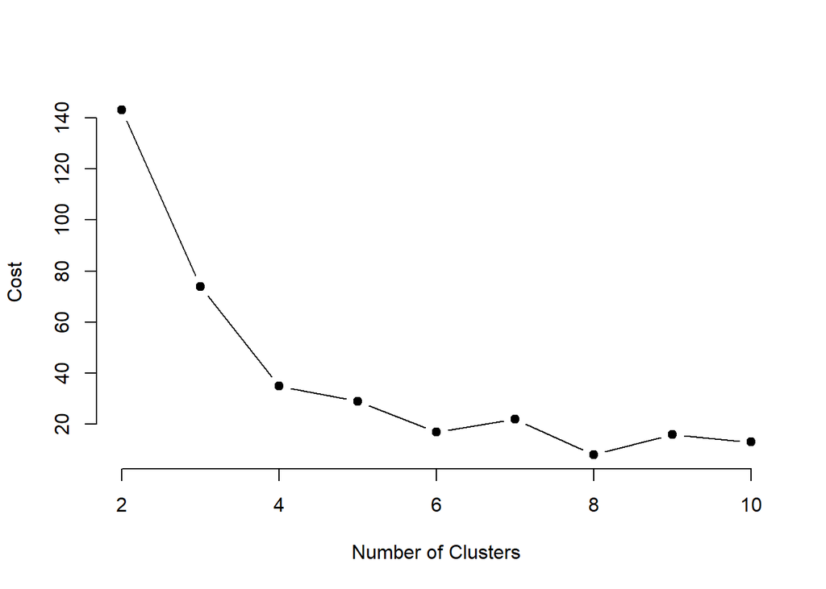

```r
plot(2:10, cost[2:10], type = "b", pch = 19, frame = FALSE,
     xlab = "Number of Clusters", ylab = "Cost")
```

```r
library(ggplot2)

k_data$cluster <- as.factor(res_clust$cluster)
table(k_data$cluster)
```

```
##
##  1  2  3  4
## 25 16 15 13
```

[figure not shown]

```r
ggplot(k_data, aes(x = sesso, y = libri, color = cluster)) +
  geom_point() +
  labs(title = "Cluster Plot")
```